# WQD7002 Project

Mobile Learning Readiness: A Case Study

## Introduction

Load R packages

```r
library(dplyr) # for data frame manipulation
library(psych) # to calculate reliability eg. cronbach's alpha
library(tidyverse) # for data manipulation and visualization
library(ggplot2) # for plotting graphs
library(stringr) # for string manipulation
library(correlation) # to calculate PPMC
library(corrplot) # for correlation graph
library(fmsb) # for radar chart
library(car) # for multiple regression chart
```

## Data Cleaning

Load the questionnaires’ raw dataset.

```r
#read dataset
rawData <- read.csv("MLRS_dataset_28th_Sept.csv")
#summary(rawData)
rawData %>% skimr::skim()
```

Data summary

| Name | Piped data |
| --- | --- |
| Number of rows | 168 |
| Number of columns | 50 |
| _______________________ |  |
| Column type frequency: |  |
| character | 34 |
| numeric | 16 |
| ________________________ |  |
| Group variables | None |

**Variable type: character**

| skim_variable | n_missing | complete_rate | min | max | empty | n_unique | whitespace |
| --- | --- | --- | --- | --- | --- | --- | --- |
| A2 | 0 | 1 | 18 | 18 | 0 | 1 | 0 |
| A3 | 0 | 1 | 3 | 16 | 0 | 11 | 0 |
| A4 | 0 | 1 | 1 | 16 | 0 | 21 | 0 |
| A5 | 0 | 1 | 1 | 22 | 0 | 22 | 0 |
| B1 | 0 | 1 | 8 | 10 | 0 | 2 | 0 |
| B2 | 0 | 1 | 6 | 9 | 0 | 3 | 0 |
| B3 | 0 | 1 | 5 | 25 | 0 | 17 | 0 |
| C1 | 0 | 1 | 15 | 94 | 0 | 23 | 0 |
| C2 | 0 | 1 | 17 | 38 | 0 | 4 | 0 |
| C3 | 0 | 1 | 8 | 10 | 0 | 2 | 0 |
| C4 | 0 | 1 | 7 | 79 | 0 | 4 | 0 |
| D1 | 0 | 1 | 8 | 51 | 0 | 8 | 0 |
| D2 | 0 | 1 | 8 | 26 | 0 | 4 | 0 |
| D3 | 0 | 1 | 8 | 44 | 0 | 7 | 0 |
| D4 | 0 | 1 | 8 | 82 | 0 | 5 | 0 |
| D5 | 0 | 1 | 3 | 119 | 0 | 12 | 0 |
| D6 | 0 | 1 | 7 | 52 | 0 | 14 | 0 |
| D7 | 0 | 1 | 8 | 90 | 0 | 7 | 0 |
| D8 | 0 | 1 | 8 | 14 | 0 | 3 | 0 |
| E1 | 0 | 1 | 8 | 46 | 0 | 7 | 0 |
| E2 | 0 | 1 | 8 | 30 | 0 | 4 | 0 |
| E3 | 0 | 1 | 8 | 25 | 0 | 5 | 0 |
| E4 | 0 | 1 | 8 | 10 | 0 | 2 | 0 |
| E5 | 0 | 1 | 8 | 73 | 0 | 4 | 0 |
| E6 | 0 | 1 | 11 | 324 | 0 | 98 | 0 |
| F1 | 0 | 1 | 8 | 11 | 0 | 3 | 0 |
| F2 | 0 | 1 | 8 | 11 | 0 | 5 | 0 |
| F3 | 0 | 1 | 8 | 37 | 0 | 6 | 0 |
| F4 | 0 | 1 | 8 | 12 | 0 | 3 | 0 |
| F5 | 0 | 1 | 8 | 30 | 0 | 5 | 0 |
| F6 | 0 | 1 | 8 | 122 | 0 | 4 | 0 |
| F7 | 0 | 1 | 8 | 11 | 0 | 4 | 0 |
| F8 | 0 | 1 | 5 | 11 | 0 | 3 | 0 |
| F9 | 0 | 1 | 8 | 34 | 0 | 4 | 0 |

**Variable type: numeric**

| skim_variable | n_missing | complete_rate | mean | sd | p0 | p25 | p50 | p75 | p100 | hist |
| --- | --- | --- | --- | --- | --- | --- | --- | --- | --- | --- |
| A1 | 0 | 1 | 46.10 | 5.06 | 37 | 43.00 | 44 | 50 | 60 | ▂▇▂▂▁ |
| G1 | 0 | 1 | 2.73 | 0.50 | 1 | 2.75 | 3 | 3 | 3 | ▁▁▂▁▇ |
| G2 | 0 | 1 | 2.79 | 0.42 | 1 | 3.00 | 3 | 3 | 3 | ▁▁▂▁▇ |
| G3 | 0 | 1 | 2.88 | 0.35 | 1 | 3.00 | 3 | 3 | 3 | ▁▁▁▁▇ |
| G4 | 0 | 1 | 2.84 | 0.38 | 1 | 3.00 | 3 | 3 | 3 | ▁▁▂▁▇ |
| G5 | 0 | 1 | 2.78 | 0.43 | 1 | 3.00 | 3 | 3 | 3 | ▁▁▂▁▇ |
| G6 | 0 | 1 | 2.80 | 0.43 | 1 | 3.00 | 3 | 3 | 3 | ▁▁▂▁▇ |
| G7 | 0 | 1 | 2.72 | 0.49 | 1 | 2.00 | 3 | 3 | 3 | ▁▁▂▁▇ |
| G8 | 0 | 1 | 2.76 | 0.50 | 1 | 3.00 | 3 | 3 | 3 | ▁▁▂▁▇ |
| G9 | 0 | 1 | 2.61 | 0.56 | 1 | 2.00 | 3 | 3 | 3 | ▁▁▃▁▇ |
| G10 | 0 | 1 | 2.62 | 0.59 | 1 | 2.00 | 3 | 3 | 3 | ▁▁▃▁▇ |
| G11 | 0 | 1 | 2.81 | 0.42 | 1 | 3.00 | 3 | 3 | 3 | ▁▁▂▁▇ |
| G12 | 0 | 1 | 2.68 | 0.54 | 1 | 2.00 | 3 | 3 | 3 | ▁▁▃▁▇ |
| G13 | 0 | 1 | 2.80 | 0.42 | 1 | 3.00 | 3 | 3 | 3 | ▁▁▂▁▇ |
| G14 | 0 | 1 | 2.67 | 0.56 | 1 | 2.00 | 3 | 3 | 3 | ▁▁▂▁▇ |
| G15 | 0 | 1 | 2.73 | 0.49 | 1 | 2.00 | 3 | 3 | 3 | ▁▁▂▁▇ |

```r
# function to normalize 3-point Likert-type-scale to 0-to-1 scale
normalize <- function(x) {
  #return ((x - min(x)) / (max(x) - min(x)))
  return ((x - 1) / 2)
}
```

### Factors

Extract Factors Data:

```r
factors <- data.frame(rawData[,6:50])

# remove column E6 (features of Islamic study learning material, unique multiple choice)
factors <- subset(factors, select = -c(E6))
# remove columns (G6-Aspect1 Awareness, G13-Aspect2 Ability, G15-Aspect5 - Software Diversity)
# factors <- subset(factors, select = -c(E6,G6,G13,G15))
```

Data Cleaning for Factors Data:

```r
#
unique(as.vector(as.matrix(factors)))
```

```
##   [1] "Yes / Ya"
##   [2] "No / Tidak"
##   [3] "Apple IOS"
##   [4] "Android"
##   [5] "Huawei"
##   [6] "Wi-Fi"
##   [7] "Broadband"
##   [8] "Hotspot"
##   [9] "Wi-Fi;Hotspot"
##  [10] "mobile data"
##  [11] "Wi-Fi;Broadband"
##  [12] "Wi-Fi;Digi"
##  [13] "Wi-Fi;DiGi "
##  [14] "Mobile data"
##  [15] "Wi-Fi;mobile data"
```

[output cut: 95 more lines]

```r
factors[factors == "Yes / Ya"] <- 1.0
factors[factors == "No / Tidak"] <- 0.0

factors[factors == "Intermediate / Tahap Pertengahan"] <- 1.0
factors[factors == "Tahap Pertengahan sehingga tingkatan 6"] <- 1.0
factors[factors == "Basic / Tahap Asas"] <- 1.0
factors[factors == "None / Tiada asas"] <- 0.0

factors[factors == "Apple IOS"] <- 1.0
factors[factors == "Android"] <- 1.0

factors[factors == "mungkin"] <- 0.5
factors[factors == "Tidak pernah"] <- 0.5
factors[factors == "Hanya membaca makna"] <- 0.5
factors[factors == "X pernah"] <- 0.5
factors[factors == "Tak belajar"] <- 0.5
factors[factors == "Tidak mencuba lagi"] <- 0.5
factors[factors == "NA"] <- 0.5
factors[factors == "Belum pernah masuk kelas bahasa arab"] <- 0.5
factors[factors == "Belum mencuba untuk belajar"] <- 0.5
factors[factors == "Mungkin"] <- 0.5
factors[factors == "tidak pernah mengikuti"] <- 0.5
factors[factors == "Tidak pernah masuk kelas"] <- 0.5
factors[factors == "hanya baca tafsir secara am"] <- 0.5
factors[factors == "In syaa allah"] <- 0.5
factors[factors == "mengikut masa yang sesuai dgn waktu kerja saya"] <- 0.5
factors[factors == "Depends on free time"] <- 0.5
factors[factors == "when i'm want to"] <- 0.5
factors[factors == "Learn online"] <- 0.5
factors[factors == " Depends on the free time"] <- 0.5
factors[factors == "Boleh cuba"] <- 0.5
factors[factors == "Not sure"] <- 0.5
factors[factors == "Depends."] <- 0.5
factors[factors == "I don't know"] <- 0.5
factors[factors == "Maybe"] <- 0.5
factors[factors == "Belum tentu"] <- 0.5

factors[factors == "Tidak, kerana kurang penggunaan bahasa Arab. Mengambil bahagian untuk menolong."] <- 0.5
factors[factors == "I have never learnt arabic"] <- 0.5
factors[factors == "only simple word easy"] <- 0.5
factors[factors == "Tak pernah cuba hafal"] <- 0.5
factors[factors == "Biasanya menghafal sahaja."] <- 0.5
factors[factors == "Menghafal dan akronim."] <- 0.5
factors[factors == "Tidak menggunakan Bahasa Arab dlm komunikasi"] <- 0.5
factors[factors == "I dont communicate in arabic"] <- 0.5
factors[factors == "Rujuk terjemahan untuk faham sahaja"] <- 0.5
factors[factors == "Tidak pernah menghadiri kelas bahasa Arab"] <- 0.5
factors[factors == "Never attend any arabic class"] <- 0.5
factors[factors == "Tiada keperluan kecuali untuk membaca al-Quran."] <- 0.5
factors[factors == "Belum pernah belajar bahasa Arab"] <- 0.5
factors[factors == "tidak pernah belajar secara langsung"] <- 0.5
factors[factors == "Tidak ketemu lagi yang sesuai untuk orang dewasa"] <- 0.5
factors[factors == "Just try to learn using terjemahan quran perksts"] <- 0.5
factors[factors == "tidak pernah mempunyai pegalaman belajar bahasa arab"] <- 0.5
factors[factors == "Tiada siaran yang sesuai untuk orang dewasa mempelajari bahasa Arab"] <- 0.5
factors[factors == "tidak pernah mencuba"] <- 0.5
factors[factors == "Apabila ada masa terluang"] <- 0.5
factors[factors == "Pada tempat dan masa yg sesuai"] <- 0.5
factors[factors == "Tidak pasti"] <- 0.5
factors[factors == "No comment as have never tried before"] <- 0.5
factors[factors == "Dependent of the response rate"] <- 0.5
factors[factors == "Depends on the method of teaching "] <- 0.5

factors[factors == "Working purpose"] <- 0.5
factors[factors == "Some of the words"] <- 0.5
factors[factors == "Boleh menghafal jika berusaha dgn lebih bersungguh2"] <- 0.5
factors[factors == "Tak pernah belajar"] <- 0.5
factors[factors == "Sometimes "] <- 0.5
factors[factors == "Sederhana penggunaan bahasa Arab. "] <- 0.5
factors[factors == "Saya memahami bila selalu membaca translation dan saya juga ada asas bahasa Arab. "] <- 0.5
factors[factors == "N/A"] <- 0.5
factors[factors == "Saya todak meletakkan fokus dalam prmbelajaran bahasa Arab. InshaAllah kalau saya berusaha, apa2 kaedah boleh berjaya. "] <- 0.5
factors[factors == "Havent tried on any"] <- 0.5
factors[factors == "Saya rasa kalau kita berlatih dgn kerap, kita boleh menguasai bahasa Arab dgn lebih baik. "] <- 0.5
factors[factors == "Prefer English"] <- 0.5
factors[factors == "Halaqah needs two way communication with an educator. Not via written Q&A"] <- 0.5
factors[factors == "Yes, perlu tapi ia tidak dapat menggantikan keperluan belajar secara formal. Ia hanya sebagai alat membantu pembelajaran. "] <- 0.5
```

Normalize data to range 0-1

```r
factors$G1 <- normalize(rawData$G1)
factors$G2 <- normalize(rawData$G2)
factors$G3 <- normalize(rawData$G3)
factors$G4 <- normalize(rawData$G4)
factors$G5 <- normalize(rawData$G5)
factors$G6 <- normalize(rawData$G6)
factors$G7 <- normalize(rawData$G7)
factors$G8 <- normalize(rawData$G8)
factors$G9 <- normalize(rawData$G9)
factors$G10 <- normalize(rawData$G10)
factors$G11 <- normalize(rawData$G11)
factors$G12 <- normalize(rawData$G12)
factors$G13 <- normalize(rawData$G13)
factors$G14 <- normalize(rawData$G14)
factors$G15 <- normalize(rawData$G15)

# convert all columns to numeric
factors <- data.frame(sapply(factors, function(x) as.numeric(as.character(x))))

factors %>% skimr::skim()
```

Data summary

| Name | Piped data |
| --- | --- |
| Number of rows | 168 |
| Number of columns | 44 |
| _______________________ |  |
| Column type frequency: |  |
| numeric | 44 |
| ________________________ |  |
| Group variables | None |

**Variable type: numeric**

| skim_variable | n_missing | complete_rate | mean | sd | p0 | p25 | p50 | p75 | p100 | hist |
| --- | --- | --- | --- | --- | --- | --- | --- | --- | --- | --- |
| B1 | 0 | 1.00 | 0.99 | 0.08 | 0.0 | 1.00 | 1.0 | 1.0 | 1.0 | ▁▁▁▁▇ |
| B2 | 1 | 0.99 | 1.00 | 0.00 | 1.0 | 1.00 | 1.0 | 1.0 | 1.0 | ▁▁▇▁▁ |
| B3 | 168 | 0.00 | NaN | NA | NA | NA | NA | NA | NA |  |
| C1 | 167 | 0.01 | 0.50 | NA | 0.5 | 0.50 | 0.5 | 0.5 | 0.5 | ▁▁▇▁▁ |
| C2 | 0 | 1.00 | 0.54 | 0.50 | 0.0 | 0.00 | 1.0 | 1.0 | 1.0 | ▇▁▁▁▇ |
| C3 | 0 | 1.00 | 0.31 | 0.46 | 0.0 | 0.00 | 0.0 | 1.0 | 1.0 | ▇▁▁▁▃ |
| C4 | 0 | 1.00 | 0.95 | 0.21 | 0.0 | 1.00 | 1.0 | 1.0 | 1.0 | ▁▁▁▁▇ |
| D1 | 0 | 1.00 | 0.89 | 0.30 | 0.0 | 1.00 | 1.0 | 1.0 | 1.0 | ▁▁▁▁▇ |
| D2 | 0 | 1.00 | 0.90 | 0.29 | 0.0 | 1.00 | 1.0 | 1.0 | 1.0 | ▁▁▁▁▇ |
| D3 | 0 | 1.00 | 0.93 | 0.25 | 0.0 | 1.00 | 1.0 | 1.0 | 1.0 | ▁▁▁▁▇ |
| D4 | 0 | 1.00 | 0.86 | 0.34 | 0.0 | 1.00 | 1.0 | 1.0 | 1.0 | ▁▁▁▁▇ |
| D5 | 0 | 1.00 | 0.66 | 0.46 | 0.0 | 0.00 | 1.0 | 1.0 | 1.0 | ▃▁▁▁▇ |
| D6 | 0 | 1.00 | 0.66 | 0.46 | 0.0 | 0.00 | 1.0 | 1.0 | 1.0 | ▃▁▁▁▇ |
| D7 | 0 | 1.00 | 0.91 | 0.27 | 0.0 | 1.00 | 1.0 | 1.0 | 1.0 | ▁▁▁▁▇ |
| D8 | 0 | 1.00 | 0.93 | 0.25 | 0.0 | 1.00 | 1.0 | 1.0 | 1.0 | ▁▁▁▁▇ |
| E1 | 0 | 1.00 | 0.94 | 0.21 | 0.0 | 1.00 | 1.0 | 1.0 | 1.0 | ▁▁▁▁▇ |
| E2 | 0 | 1.00 | 0.96 | 0.19 | 0.0 | 1.00 | 1.0 | 1.0 | 1.0 | ▁▁▁▁▇ |
| E3 | 0 | 1.00 | 0.97 | 0.15 | 0.0 | 1.00 | 1.0 | 1.0 | 1.0 | ▁▁▁▁▇ |
| E4 | 0 | 1.00 | 1.00 | 0.04 | 0.5 | 1.00 | 1.0 | 1.0 | 1.0 | ▁▁▁▁▇ |
| E5 | 0 | 1.00 | 0.93 | 0.25 | 0.0 | 1.00 | 1.0 | 1.0 | 1.0 | ▁▁▁▁▇ |
| F1 | 0 | 1.00 | 0.99 | 0.09 | 0.0 | 1.00 | 1.0 | 1.0 | 1.0 | ▁▁▁▁▇ |
| F2 | 0 | 1.00 | 0.96 | 0.17 | 0.0 | 1.00 | 1.0 | 1.0 | 1.0 | ▁▁▁▁▇ |
| F3 | 0 | 1.00 | 0.98 | 0.13 | 0.0 | 1.00 | 1.0 | 1.0 | 1.0 | ▁▁▁▁▇ |
| F4 | 0 | 1.00 | 0.99 | 0.09 | 0.0 | 1.00 | 1.0 | 1.0 | 1.0 | ▁▁▁▁▇ |
| F5 | 0 | 1.00 | 0.97 | 0.15 | 0.0 | 1.00 | 1.0 | 1.0 | 1.0 | ▁▁▁▁▇ |
| F6 | 0 | 1.00 | 0.98 | 0.12 | 0.0 | 1.00 | 1.0 | 1.0 | 1.0 | ▁▁▁▁▇ |
| F7 | 0 | 1.00 | 0.95 | 0.22 | 0.0 | 1.00 | 1.0 | 1.0 | 1.0 | ▁▁▁▁▇ |
| F8 | 0 | 1.00 | 0.99 | 0.05 | 0.5 | 1.00 | 1.0 | 1.0 | 1.0 | ▁▁▁▁▇ |
| F9 | 0 | 1.00 | 0.96 | 0.18 | 0.0 | 1.00 | 1.0 | 1.0 | 1.0 | ▁▁▁▁▇ |
| G1 | 0 | 1.00 | 0.86 | 0.25 | 0.0 | 0.88 | 1.0 | 1.0 | 1.0 | ▁▁▂▁▇ |
| G2 | 0 | 1.00 | 0.90 | 0.21 | 0.0 | 1.00 | 1.0 | 1.0 | 1.0 | ▁▁▂▁▇ |
| G3 | 0 | 1.00 | 0.94 | 0.17 | 0.0 | 1.00 | 1.0 | 1.0 | 1.0 | ▁▁▁▁▇ |
| G4 | 0 | 1.00 | 0.92 | 0.19 | 0.0 | 1.00 | 1.0 | 1.0 | 1.0 | ▁▁▂▁▇ |
| G5 | 0 | 1.00 | 0.89 | 0.21 | 0.0 | 1.00 | 1.0 | 1.0 | 1.0 | ▁▁▂▁▇ |
| G6 | 0 | 1.00 | 0.90 | 0.21 | 0.0 | 1.00 | 1.0 | 1.0 | 1.0 | ▁▁▂▁▇ |
| G7 | 0 | 1.00 | 0.86 | 0.24 | 0.0 | 0.50 | 1.0 | 1.0 | 1.0 | ▁▁▂▁▇ |
| G8 | 0 | 1.00 | 0.88 | 0.25 | 0.0 | 1.00 | 1.0 | 1.0 | 1.0 | ▁▁▂▁▇ |
| G9 | 0 | 1.00 | 0.80 | 0.28 | 0.0 | 0.50 | 1.0 | 1.0 | 1.0 | ▁▁▃▁▇ |
| G10 | 0 | 1.00 | 0.81 | 0.29 | 0.0 | 0.50 | 1.0 | 1.0 | 1.0 | ▁▁▃▁▇ |
| G11 | 0 | 1.00 | 0.90 | 0.21 | 0.0 | 1.00 | 1.0 | 1.0 | 1.0 | ▁▁▂▁▇ |
| G12 | 0 | 1.00 | 0.84 | 0.27 | 0.0 | 0.50 | 1.0 | 1.0 | 1.0 | ▁▁▃▁▇ |
| G13 | 0 | 1.00 | 0.90 | 0.21 | 0.0 | 1.00 | 1.0 | 1.0 | 1.0 | ▁▁▂▁▇ |
| G14 | 0 | 1.00 | 0.84 | 0.28 | 0.0 | 0.50 | 1.0 | 1.0 | 1.0 | ▁▁▂▁▇ |
| G15 | 0 | 1.00 | 0.86 | 0.24 | 0.0 | 0.50 | 1.0 | 1.0 | 1.0 | ▁▁▂▁▇ |

### Aspects

Extract Aspects Data

```r
aspects <- data.frame(rawData[,6:50])

# remove column E6 (features of Islamic study learning material, unique multiple choice)
aspects <- subset(aspects, select = -c(E6))
# remove columns (G6-Aspect1 Awareness, G13-Aspect2 Ability, G15-Aspect5 - Software Diversity)
# aspects <- subset(aspects, select = -c(E6,G6,G13,G15))
```

Data Cleaning for Factors Data:

```r
#
unique(as.vector(as.matrix(aspects)))
```

```
##   [1] "Yes / Ya"
##   [2] "No / Tidak"
##   [3] "Apple IOS"
##   [4] "Android"
##   [5] "Huawei"
##   [6] "Wi-Fi"
##   [7] "Broadband"
##   [8] "Hotspot"
##   [9] "Wi-Fi;Hotspot"
##  [10] "mobile data"
##  [11] "Wi-Fi;Broadband"
##  [12] "Wi-Fi;Digi"
##  [13] "Wi-Fi;DiGi "
##  [14] "Mobile data"
##  [15] "Wi-Fi;mobile data"
```

[output cut: 95 more lines]

```r
aspects[aspects == "Yes / Ya"] <- 1.0
aspects[aspects == "No / Tidak"] <- 0.0

aspects[aspects == "Intermediate / Tahap Pertengahan"] <- 1.0
aspects[aspects == "Tahap Pertengahan sehingga tingkatan 6"] <- 1.0
aspects[aspects == "Basic / Tahap Asas"] <- 1.0
aspects[aspects == "None / Tiada asas"] <- 0.0

aspects[aspects == "Apple IOS"] <- 1.0
aspects[aspects == "Android"] <- 1.0

aspects[aspects == "mungkin"] <- 0.5
aspects[aspects == "Tidak pernah"] <- 0.5
aspects[aspects == "Hanya membaca makna"] <- 0.5
aspects[aspects == "X pernah"] <- 0.5
aspects[aspects == "Tak belajar"] <- 0.5
aspects[aspects == "Tidak mencuba lagi"] <- 0.5
aspects[aspects == "NA"] <- 0.5
aspects[aspects == "Belum pernah masuk kelas bahasa arab"] <- 0.5
aspects[aspects == "Belum mencuba untuk belajar"] <- 0.5
aspects[aspects == "Mungkin"] <- 0.5
aspects[aspects == "tidak pernah mengikuti"] <- 0.5
aspects[aspects == "Tidak pernah masuk kelas"] <- 0.5
aspects[aspects == "hanya baca tafsir secara am"] <- 0.5
aspects[aspects == "In syaa allah"] <- 0.5
aspects[aspects == "mengikut masa yang sesuai dgn waktu kerja saya"] <- 0.5
aspects[aspects == "Depends on free time"] <- 0.5
aspects[aspects == "when i'm want to"] <- 0.5
aspects[aspects == "Learn online"] <- 0.5
aspects[aspects == " Depends on the free time"] <- 0.5
aspects[aspects == "Boleh cuba"] <- 0.5
aspects[aspects == "Not sure"] <- 0.5
aspects[aspects == "Depends."] <- 0.5
aspects[aspects == "I don't know"] <- 0.5
aspects[aspects == "Maybe"] <- 0.5
aspects[aspects == "Belum tentu"] <- 0.5

aspects[aspects == "Tidak, kerana kurang penggunaan bahasa Arab. Mengambil bahagian untuk menolong."] <- 0.5
aspects[aspects == "I have never learnt arabic"] <- 0.5
aspects[aspects == "only simple word easy"] <- 0.5
aspects[aspects == "Tak pernah cuba hafal"] <- 0.5
aspects[aspects == "Biasanya menghafal sahaja."] <- 0.5
aspects[aspects == "Menghafal dan akronim."] <- 0.5
aspects[aspects == "Tidak menggunakan Bahasa Arab dlm komunikasi"] <- 0.5
aspects[aspects == "I dont communicate in arabic"] <- 0.5
aspects[aspects == "Rujuk terjemahan untuk faham sahaja"] <- 0.5
aspects[aspects == "Tidak pernah menghadiri kelas bahasa Arab"] <- 0.5
aspects[aspects == "Never attend any arabic class"] <- 0.5
aspects[aspects == "Tiada keperluan kecuali untuk membaca al-Quran."] <- 0.5
aspects[aspects == "Belum pernah belajar bahasa Arab"] <- 0.5
aspects[aspects == "tidak pernah belajar secara langsung"] <- 0.5
aspects[aspects == "Tidak ketemu lagi yang sesuai untuk orang dewasa"] <- 0.5
aspects[aspects == "Just try to learn using terjemahan quran perksts"] <- 0.5
aspects[aspects == "tidak pernah mempunyai pegalaman belajar bahasa arab"] <- 0.5
aspects[aspects == "Tiada siaran yang sesuai untuk orang dewasa mempelajari bahasa Arab"] <- 0.5
aspects[aspects == "tidak pernah mencuba"] <- 0.5
aspects[aspects == "Apabila ada masa terluang"] <- 0.5
aspects[aspects == "Pada tempat dan masa yg sesuai"] <- 0.5
aspects[aspects == "Tidak pasti"] <- 0.5
aspects[aspects == "No comment as have never tried before"] <- 0.5
aspects[aspects == "Dependent of the response rate"] <- 0.5
aspects[aspects == "Depends on the method of teaching "] <- 0.5

aspects[aspects == "Working purpose"] <- 0.5
aspects[aspects == "Some of the words"] <- 0.5
aspects[aspects == "Boleh menghafal jika berusaha dgn lebih bersungguh2"] <- 0.5
aspects[aspects == "Tak pernah belajar"] <- 0.5
aspects[aspects == "Sometimes "] <- 0.5
aspects[aspects == "Sederhana penggunaan bahasa Arab. "] <- 0.5
aspects[aspects == "Saya memahami bila selalu membaca translation dan saya juga ada asas bahasa Arab. "] <- 0.5
aspects[aspects == "N/A"] <- 0.5
aspects[aspects == "Saya todak meletakkan fokus dalam prmbelajaran bahasa Arab. InshaAllah kalau saya berusaha, apa2 kaedah boleh berjaya. "] <- 0.5
aspects[aspects == "Havent tried on any"] <- 0.5
aspects[aspects == "Saya rasa kalau kita berlatih dgn kerap, kita boleh menguasai bahasa Arab dgn lebih baik. "] <- 0.5
aspects[aspects == "Prefer English"] <- 0.5
aspects[aspects == "Halaqah needs two way communication with an educator. Not via written Q&A"] <- 0.5
aspects[aspects == "Yes, perlu tapi ia tidak dapat menggantikan keperluan belajar secara formal. Ia hanya sebagai alat membantu pembelajaran. "] <- 0.5
```

Normalize data to range 0-1

```r
aspects$G1 <- normalize(rawData$G1)
aspects$G2 <- normalize(rawData$G2)
aspects$G3 <- normalize(rawData$G3)
aspects$G4 <- normalize(rawData$G4)
aspects$G5 <- normalize(rawData$G5)
aspects$G6 <- normalize(rawData$G6)
aspects$G7 <- normalize(rawData$G7)
aspects$G8 <- normalize(rawData$G8)
aspects$G9 <- normalize(rawData$G9)
aspects$G10 <- normalize(rawData$G10)
aspects$G11 <- normalize(rawData$G11)
aspects$G12 <- normalize(rawData$G12)
aspects$G13 <- normalize(rawData$G13)
aspects$G14 <- normalize(rawData$G14)
aspects$G15 <- normalize(rawData$G15)

# convert all columns to numeric
aspects <- data.frame(sapply(aspects, function(x) as.numeric(as.character(x))))

aspects %>% skimr::skim()
```

Data summary

| Name | Piped data |
| --- | --- |
| Number of rows | 168 |
| Number of columns | 44 |
| _______________________ |  |
| Column type frequency: |  |
| numeric | 44 |
| ________________________ |  |
| Group variables | None |

**Variable type: numeric**

| skim_variable | n_missing | complete_rate | mean | sd | p0 | p25 | p50 | p75 | p100 | hist |
| --- | --- | --- | --- | --- | --- | --- | --- | --- | --- | --- |
| B1 | 0 | 1.00 | 0.99 | 0.08 | 0.0 | 1.00 | 1.0 | 1.0 | 1.0 | ▁▁▁▁▇ |
| B2 | 1 | 0.99 | 1.00 | 0.00 | 1.0 | 1.00 | 1.0 | 1.0 | 1.0 | ▁▁▇▁▁ |
| B3 | 168 | 0.00 | NaN | NA | NA | NA | NA | NA | NA |  |
| C1 | 167 | 0.01 | 0.50 | NA | 0.5 | 0.50 | 0.5 | 0.5 | 0.5 | ▁▁▇▁▁ |
| C2 | 0 | 1.00 | 0.54 | 0.50 | 0.0 | 0.00 | 1.0 | 1.0 | 1.0 | ▇▁▁▁▇ |
| C3 | 0 | 1.00 | 0.31 | 0.46 | 0.0 | 0.00 | 0.0 | 1.0 | 1.0 | ▇▁▁▁▃ |
| C4 | 0 | 1.00 | 0.95 | 0.21 | 0.0 | 1.00 | 1.0 | 1.0 | 1.0 | ▁▁▁▁▇ |
| D1 | 0 | 1.00 | 0.89 | 0.30 | 0.0 | 1.00 | 1.0 | 1.0 | 1.0 | ▁▁▁▁▇ |
| D2 | 0 | 1.00 | 0.90 | 0.29 | 0.0 | 1.00 | 1.0 | 1.0 | 1.0 | ▁▁▁▁▇ |
| D3 | 0 | 1.00 | 0.93 | 0.25 | 0.0 | 1.00 | 1.0 | 1.0 | 1.0 | ▁▁▁▁▇ |
| D4 | 0 | 1.00 | 0.86 | 0.34 | 0.0 | 1.00 | 1.0 | 1.0 | 1.0 | ▁▁▁▁▇ |
| D5 | 0 | 1.00 | 0.66 | 0.46 | 0.0 | 0.00 | 1.0 | 1.0 | 1.0 | ▃▁▁▁▇ |
| D6 | 0 | 1.00 | 0.66 | 0.46 | 0.0 | 0.00 | 1.0 | 1.0 | 1.0 | ▃▁▁▁▇ |
| D7 | 0 | 1.00 | 0.91 | 0.27 | 0.0 | 1.00 | 1.0 | 1.0 | 1.0 | ▁▁▁▁▇ |
| D8 | 0 | 1.00 | 0.93 | 0.25 | 0.0 | 1.00 | 1.0 | 1.0 | 1.0 | ▁▁▁▁▇ |
| E1 | 0 | 1.00 | 0.94 | 0.21 | 0.0 | 1.00 | 1.0 | 1.0 | 1.0 | ▁▁▁▁▇ |
| E2 | 0 | 1.00 | 0.96 | 0.19 | 0.0 | 1.00 | 1.0 | 1.0 | 1.0 | ▁▁▁▁▇ |
| E3 | 0 | 1.00 | 0.97 | 0.15 | 0.0 | 1.00 | 1.0 | 1.0 | 1.0 | ▁▁▁▁▇ |
| E4 | 0 | 1.00 | 1.00 | 0.04 | 0.5 | 1.00 | 1.0 | 1.0 | 1.0 | ▁▁▁▁▇ |
| E5 | 0 | 1.00 | 0.93 | 0.25 | 0.0 | 1.00 | 1.0 | 1.0 | 1.0 | ▁▁▁▁▇ |
| F1 | 0 | 1.00 | 0.99 | 0.09 | 0.0 | 1.00 | 1.0 | 1.0 | 1.0 | ▁▁▁▁▇ |
| F2 | 0 | 1.00 | 0.96 | 0.17 | 0.0 | 1.00 | 1.0 | 1.0 | 1.0 | ▁▁▁▁▇ |
| F3 | 0 | 1.00 | 0.98 | 0.13 | 0.0 | 1.00 | 1.0 | 1.0 | 1.0 | ▁▁▁▁▇ |
| F4 | 0 | 1.00 | 0.99 | 0.09 | 0.0 | 1.00 | 1.0 | 1.0 | 1.0 | ▁▁▁▁▇ |
| F5 | 0 | 1.00 | 0.97 | 0.15 | 0.0 | 1.00 | 1.0 | 1.0 | 1.0 | ▁▁▁▁▇ |
| F6 | 0 | 1.00 | 0.98 | 0.12 | 0.0 | 1.00 | 1.0 | 1.0 | 1.0 | ▁▁▁▁▇ |
| F7 | 0 | 1.00 | 0.95 | 0.22 | 0.0 | 1.00 | 1.0 | 1.0 | 1.0 | ▁▁▁▁▇ |
| F8 | 0 | 1.00 | 0.99 | 0.05 | 0.5 | 1.00 | 1.0 | 1.0 | 1.0 | ▁▁▁▁▇ |
| F9 | 0 | 1.00 | 0.96 | 0.18 | 0.0 | 1.00 | 1.0 | 1.0 | 1.0 | ▁▁▁▁▇ |
| G1 | 0 | 1.00 | 0.86 | 0.25 | 0.0 | 0.88 | 1.0 | 1.0 | 1.0 | ▁▁▂▁▇ |
| G2 | 0 | 1.00 | 0.90 | 0.21 | 0.0 | 1.00 | 1.0 | 1.0 | 1.0 | ▁▁▂▁▇ |
| G3 | 0 | 1.00 | 0.94 | 0.17 | 0.0 | 1.00 | 1.0 | 1.0 | 1.0 | ▁▁▁▁▇ |
| G4 | 0 | 1.00 | 0.92 | 0.19 | 0.0 | 1.00 | 1.0 | 1.0 | 1.0 | ▁▁▂▁▇ |
| G5 | 0 | 1.00 | 0.89 | 0.21 | 0.0 | 1.00 | 1.0 | 1.0 | 1.0 | ▁▁▂▁▇ |
| G6 | 0 | 1.00 | 0.90 | 0.21 | 0.0 | 1.00 | 1.0 | 1.0 | 1.0 | ▁▁▂▁▇ |
| G7 | 0 | 1.00 | 0.86 | 0.24 | 0.0 | 0.50 | 1.0 | 1.0 | 1.0 | ▁▁▂▁▇ |
| G8 | 0 | 1.00 | 0.88 | 0.25 | 0.0 | 1.00 | 1.0 | 1.0 | 1.0 | ▁▁▂▁▇ |
| G9 | 0 | 1.00 | 0.80 | 0.28 | 0.0 | 0.50 | 1.0 | 1.0 | 1.0 | ▁▁▃▁▇ |
| G10 | 0 | 1.00 | 0.81 | 0.29 | 0.0 | 0.50 | 1.0 | 1.0 | 1.0 | ▁▁▃▁▇ |
| G11 | 0 | 1.00 | 0.90 | 0.21 | 0.0 | 1.00 | 1.0 | 1.0 | 1.0 | ▁▁▂▁▇ |
| G12 | 0 | 1.00 | 0.84 | 0.27 | 0.0 | 0.50 | 1.0 | 1.0 | 1.0 | ▁▁▃▁▇ |
| G13 | 0 | 1.00 | 0.90 | 0.21 | 0.0 | 1.00 | 1.0 | 1.0 | 1.0 | ▁▁▂▁▇ |
| G14 | 0 | 1.00 | 0.84 | 0.28 | 0.0 | 0.50 | 1.0 | 1.0 | 1.0 | ▁▁▂▁▇ |
| G15 | 0 | 1.00 | 0.86 | 0.24 | 0.0 | 0.50 | 1.0 | 1.0 | 1.0 | ▁▁▂▁▇ |

## Demographics

```r
group_age <- function(age){
  if (age >= 0 & age <= 45){
    return('40-45 Years Old')
  }else if(age > 45 & age <= 50){
    return('46-50 Years Old')
  }else if (age > 50 & age <= 55){
    return('51-55 Years Old')
  }else if (age > 55){
    return('56-60 Years Old')
  }
}

A1 <- data.frame(rawData[,c('A1')])
colnames(A1) <- c('A1')
A1$age_group <- sapply(A1$A1,group_age)
A1.stat <- A1 %>%
  group_by(age_group) %>%
  summarise(count=n())
A1.stat$percentage = A1.stat$count*100/nrow(A1)

A3 <- data.frame(rawData[,c('A3')])
colnames(A3) <- c('A3')
A3.stat <- A3 %>%
  mutate(A3 = str_replace(A3, "Sekolah Menengah", "STPM and below")) %>%
  mutate(A3 = str_replace(A3, "Sijil", "STPM and below")) %>%
  mutate(A3 = str_replace(A3, "Spm", "STPM and below")) %>%
  mutate(A3 = str_replace(A3, "SPM", "STPM and below")) %>%
  mutate(A3 = str_replace(A3, "Stpm", "STPM and below")) %>%
  mutate(A3 = str_replace(A3, "tingkatan 4", "STPM and below")) %>%
  mutate(A3 = str_replace(A3, "tingkatan 6", "STPM and below")) %>%
  mutate(A3 = str_replace(A3, "Degree", "Bachelor")) %>%
  group_by(A3) %>%
  summarise(count=n())
A3.stat$percentage = A3.stat$count*100/nrow(A3)

C2 <- data.frame(rawData[,c('C2')])
colnames(C2) <- c('C2')
C2.stat <- C2 %>%
  mutate(C2 = str_replace(C2, "None / Tiada asas", "None")) %>%
  mutate(C2 = str_replace(C2, "Basic / Tahap Asas", "Basic")) %>%
  mutate(C2 = str_replace(C2, "Tahap Pertengahan sehingga tingkatan 6", "Intermediate")) %>%
  mutate(C2 = str_replace(C2, "Intermediate / Tahap Pertengahan", "Intermediate")) %>%
  group_by(C2) %>%
  summarise(count=n())
C2.stat$percentage = C2.stat$count*100/nrow(C2)

A4 <- data.frame(rawData[,c('A4')])
colnames(A4) <- c('A4')
A4.stat <- A4 %>%
  mutate(A4 = str_replace(A4, "Kerajaan", "Government Sector")) %>%
  mutate(A4 = str_replace(A4, "Swasta", "Private Sector")) %>%
  mutate(A4 = str_replace(A4, "Surirumah", "Housewife")) %>%
  mutate(A4 = str_replace(A4, "Bekerja sendiri", "Self Employed")) %>%
  mutate(A4 = str_replace(A4, "tiada", "Not Disclosed")) %>%
  mutate(A4 = str_replace(A4, "Housewife ", "Housewife")) %>%
  mutate(A4 = str_replace(A4, "Sendiri", "Self Employed")) %>%
  mutate(A4 = str_replace(A4, "Tnb", "Private Sector")) %>%
  mutate(A4 = str_replace(A4, "surirumah", "Housewife")) %>%
  mutate(A4 = str_replace(A4, "Pesara Kerajaan", "Government Setorrvant")) %>%
  mutate(A4 = str_replace(A4, "Suri rumah", "Housewife")) %>%
  mutate(A4 = str_replace(A4, "House wife", "Housewife")) %>%
  mutate(A4 = str_replace(A4, "Self Employed", "Self Employed")) %>%
  mutate(A4 = str_replace(A4, "Self employed", "Self Employed")) %>%
  mutate(A4 = str_replace(A4, "GLC", "Private Sector")) %>%
  mutate(A4 = str_replace(A4, "Homemaker", "Housewife")) %>%
  mutate(A4 = str_replace(A4, "Suri rumahtangga", "Housewife")) %>%
  mutate(A4 = str_replace(A4, "Housewife", "Housewife")) %>%
  mutate(A4 = str_replace(A4, "Suri Rumah", "Housewife")) %>%
  mutate(A4 = str_replace(A4, "-", "Not Disclosed")) %>%
  mutate(A4 = str_replace(A4, "Suri Rumah ", "Housewife")) %>%
  mutate(A4 = str_replace(A4, "Pesara Government Sector", "Government Sector")) %>%
  mutate(A4 = str_replace(A4, "Housewifetangga", "Housewife")) %>%
  mutate(A4 = str_replace(A4, "Housewife ", "Housewife")) %>%
  group_by(A4) %>%
  summarise(count=n())
A4.stat$percentage = A4.stat$count*100/nrow(A4)

A1.stat
```

```
## # A tibble: 4 x 3
##   age_group       count percentage
##   <chr>           <int>      <dbl>
## 1 40-45 Years Old    96      57.1
## 2 46-50 Years Old    36      21.4
## 3 51-55 Years Old    25      14.9
## 4 56-60 Years Old    11       6.55
```

```r
A3.stat
```

```
## # A tibble: 5 x 3
##   A3             count percentage
##   <chr>          <int>      <dbl>
## 1 Bachelor          86      51.2
## 2 Diploma           26      15.5
## 3 Master            30      17.9
## 4 PhD               10       5.95
## 5 STPM and below    16       9.52
```

```r
C2.stat
```

```
## # A tibble: 3 x 3
##   C2           count percentage
##   <chr>        <int>      <dbl>
## 1 Basic           83      49.4
## 2 Intermediate     7       4.17
## 3 None            78      46.4
```

```r
A4.stat
```

```
## # A tibble: 5 x 3
##   A4                count percentage
##   <chr>             <int>      <dbl>
## 1 Government Sector    72      42.9
## 2 Housewife            25      14.9
## 3 Not Disclosed         2       1.19
## 4 Private Sector       60      35.7
## 5 Self Employed         9       5.36
```

## Preferences

```r
Q.E6 <- data.frame(rawData[,c('E6')])
names(Q.E6)[1] <- "E6"
Q.E6 <- Q.E6 %>%
  mutate(E6 = str_replace(E6, "Choose tutor/ Pilih tutor.", "1")) %>%
  mutate(E6 = str_replace(E6, "In-App communication/ Komunikasi dalam Aplikasi", "2")) %>%
  mutate(E6 = str_replace(E6, "Reminder or Push Notification / Pemberitahuan Peringatan atau Notifikasi", "3")) %>%
  mutate(E6 = str_replace(E6, "Offline learning / Pembelajaran luar talian", "4")) %>%
  mutate(E6 = str_replace(E6, "Intuitive Interface / Antara Muka Intuitif \\(mudah difahami\\)", "5")) %>%
  mutate(E6 = str_replace(E6, "Quiz / Kuiz", "6")) %>%
  mutate(E6 = str_replace(E6, "Progress bar / Bar Kemajuan", "7")) %>%
  mutate(E6 = str_replace(E6, "Gamification / Gamifikasi", "8")) %>%
  mutate(E6 = str_replace(E6, "Option for flexible learning", "9"))


data.E6 <- data.frame(str_count(Q.E6$E6, "1"))
data.E6$O2 <- data.frame(str_count(Q.E6$E6, "2"))
data.E6$O3 <- data.frame(str_count(Q.E6$E6, "3"))
data.E6$O4 <- data.frame(str_count(Q.E6$E6, "4"))
data.E6$O5 <- data.frame(str_count(Q.E6$E6, "5"))
data.E6$O6 <- data.frame(str_count(Q.E6$E6, "6"))
data.E6$O7 <- data.frame(str_count(Q.E6$E6, "7"))
data.E6$O8 <- data.frame(str_count(Q.E6$E6, "8"))
data.E6$O9 <- data.frame(str_count(Q.E6$E6, "9"))

#colnames(data.E6) <- c('Choose tutor','In-App communication','Reminder or Push Notification','Offline #learning','Intuitive Interface','Quiz','Progress bar','Gamification','Option for flexible learning')

#names(data.E6)[1] <- "O1"
#names(data.E6)[2] <- "O2"
#names(data.E6)[3] <- "O3"
#names(data.E6)[4] <- "O4"
#names(data.E6)[5] <- "O5"
#names(data.E6)[6] <- "O6"
#names(data.E6)[7] <- "O7"
#names(data.E6)[8] <- "O8"
#names(data.E6)[9] <- "O9"

data.pref <- data.E6
data.pref$A3 <- rawData$A3

data.pref <- data.pref %>%
  mutate(A3 = str_replace(A3, "Sekolah Menengah", "STPM and below")) %>%
  mutate(A3 = str_replace(A3, "Sijil", "STPM and below")) %>%
  mutate(A3 = str_replace(A3, "Spm", "STPM and below")) %>%
  mutate(A3 = str_replace(A3, "SPM", "STPM and below")) %>%
  mutate(A3 = str_replace(A3, "Stpm", "STPM and below")) %>%
  mutate(A3 = str_replace(A3, "tingkatan 4", "STPM and below")) %>%
  mutate(A3 = str_replace(A3, "tingkatan 6", "STPM and below")) %>%
  mutate(A3 = str_replace(A3, "Degree", "Bachelor"))

colnames(data.pref) <- c('O1','O2','O3','O4','O5','O6','O7','O8','O9','A3')
```

```r
test <- data.pref %>% group_by(A3) %>%
  summarise(O1=sum(O1),O2=sum(O2),O3=sum(O3),O4=sum(O4),O5=sum(O5),O6=sum(O6),O7=sum(O7),O8=sum(O8),O9=sum(O9))
#  summarise(O1=sum(O1)*100/nrow(data.pref),O2=sum(O2)*100/nrow(data.pref),O3=sum(O3)*100/nrow(data.pref),O4=sum(O4)*#100/nrow(data.pref),O5=sum(O5)*100/nrow(data.pref),O6=sum(O6)*100/nrow(data.pref),O7=sum(O7)*100/nrow(data.pref),O8=#sum(O8)*100/nrow(data.pref),O9=sum(O9)*100/nrow(data.pref))
test <- subset(test, select=-O9)
test
```

```
## # A tibble: 5 x 9
##   A3                O1    O2    O3    O4    O5    O6    O7    O8
##   <chr>          <int> <int> <int> <int> <int> <int> <int> <int>
## 1 Bachelor          44    72    32    35    34    53    28    41
## 2 Diploma           10    24    13     8    10    18     6    10
## 3 Master            23    24    13    14    15    20    13    18
## 4 PhD                8     9     8     8     9    10     8     7
## 5 STPM and below    10    10    10    12     7    10     6     5
```

```r
#normalized <- function(x) {
#  return((x - min(x)) / (max(x) - min(x)))
#}
#test['O1'] <- normalized(test['O1'])
#test['O2'] <- normalized(test['O2'])
#test['O3'] <- normalized(test['O3'])
#test['O4'] <- normalized(test['O4'])
#test['O5'] <- normalized(test['O5'])
#test['O6'] <- normalized(test['O6'])
#test['O7'] <- normalized(test['O7'])
#test['O8'] <- normalized(test['O8'])
#test['O9'] <- normalized(test['O9'])
#test

df <- subset(test, select=-A3)
#df <- subset(df, select=-O9)
#df

scl <- rowSums(df)
v1 <- df[1,]*100/scl[1]
v2 <- df[2,]*100/scl[2]
v3 <- df[3,]*100/scl[3]
v4 <- df[4,]*100/scl[4]
v5 <- df[5,]*100/scl[5]

#df1 <- data.frame(rbind(rep(25,9),rep(0,9),v1,v2,v3,v4,v5))
df1 <- data.frame(rbind(rep(25,8),rep(0,8),v1,v2,v3,v4,v5))
#df1


rownames(df1) <- c('max','min','Bachelor','Diploma','Master','PhD','STPM and below')
#colnames(df1) <- c('Choose tutor','In-App communication','Push Notification','Offline learning','Intuitive #Interface','Quiz','Progress bar','Gamification','Flexible learning')
colnames(df1) <- c('Choose Tutor','In-App Communication','Push Notification','Offline Learning','Intuitive Interface','Quiz','Progress Bar','Gamification')
df1
```

```
##                Choose Tutor In-App Communication Push Notification
## max                25.00000             25.00000         25.000000
## min                 0.00000              0.00000          0.000000
## Bachelor           12.97935             21.23894          9.439528
## Diploma            10.10101             24.24242         13.131313
## Master             16.42857             17.14286          9.285714
## PhD                11.94030             13.43284         11.940299
## STPM and below     14.28571             14.28571         14.285714
##                Offline Learning Intuitive Interface     Quiz Progress Bar
## max                   25.000000            25.00000 25.00000    25.000000
## min                    0.000000             0.00000  0.00000     0.000000
## Bachelor              10.324484            10.02950 15.63422     8.259587
## Diploma                8.080808            10.10101 18.18182     6.060606
## Master                10.000000            10.71429 14.28571     9.285714
## PhD                   11.940299            13.43284 14.92537    11.940299
## STPM and below        17.142857            10.00000 14.28571     8.571429
##                Gamification
## max               25.000000
## min                0.000000
## Bachelor          12.094395
## Diploma           10.101010
## Master            12.857143
## PhD               10.447761
## STPM and below     7.142857
```

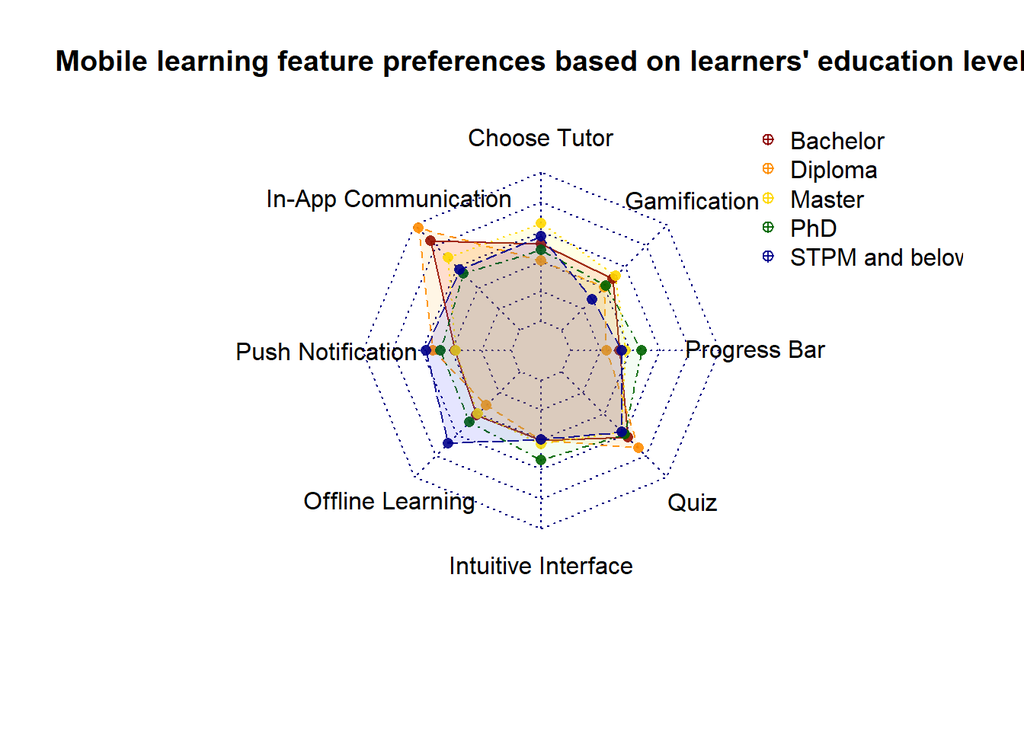

```r
# Define fill colors
colors_fill <- c(scales::alpha("red", 0.1),
                 scales::alpha("orange", 0.1),
                 scales::alpha("yellow", 0.1),
                 scales::alpha("lightgreen", 0.1),
                 scales::alpha("blue", 0.1),
                 scales::alpha("purple", 0.1),
                 scales::alpha("gray", 0.1),
                 scales::alpha("cyan", 0.1))

# Define line colors
colors_line <-  c(scales::alpha("darkred", 0.9),
                  scales::alpha("darkorange", 0.9),
                  scales::alpha("gold", 0.9),
                  scales::alpha("darkgreen", 0.9),
                  scales::alpha("darkblue", 0.9),
                  scales::alpha("purple", 0.9),
                  scales::alpha("darkgray", 0.9),
                  scales::alpha("cyan", 0.9))

radarchart(df1,
           seg = 5,  # Number of axis segments
           title = "Mobile learning feature preferences based on learners' education level",
           pcol = colors_line,
           pfcol = colors_fill,
           plwd = 1)

legend(x=1.15,
       y=1.35,
       legend = rownames(df1[-c(1,2),]),
       bty = "n", pch=10 , col = colors_line, cex = 1.00, pt.cex = 1.0)
```

```r
data.pref <- data.E6
data.pref$A1 <- rawData$A1

group_age <- function(age){
  if (age >= 0 & age <= 45){
    return('40-45 Years Old')
  }else if(age > 45 & age <= 50){
    return('46-50 Years Old')
  }else if (age > 50 & age <= 55){
    return('51-55 Years Old')
  }else if (age > 55){
    return('56-60 Years Old')
  }
}

data.pref$age_group <- sapply(data.pref$A1,group_age)
#churn_df$tenure_group <- as.factor(churn_df$tenure_group)

df <- subset(data.pref, select=-A1)
df <- subset(df, select=-O9)

colnames(df) <- c('O1','O2','O3','O4','O5','O6','O7','O8','age_group')

test <- df %>% group_by(age_group) %>%
  summarise(O1=sum(O1),O2=sum(O2),O3=sum(O3),O4=sum(O4),O5=sum(O5),O6=sum(O6),O7=sum(O7),O8=sum(O8))
#  summarise(O1=sum(O1)*100/nrow(data.pref),O2=sum(O2)*100/nrow(data.pref),O3=sum(O3)*100/nrow(data.pref),O4=sum(O4)*#100/nrow(data.pref),O5=sum(O5)*100/nrow(data.pref),O6=sum(O6)*100/nrow(data.pref),O7=sum(O7)*100/nrow(data.pref),O8=#sum(O8)*100/nrow(data.pref),O9=sum(O9)*100/nrow(data.pref))
test
```

```
## # A tibble: 4 x 9
##   age_group          O1    O2    O3    O4    O5    O6    O7    O8
##   <chr>           <int> <int> <int> <int> <int> <int> <int> <int>
## 1 40-45 Years Old    53    83    36    40    45    65    31    49
## 2 46-50 Years Old    19    28    22    19    18    20    14    18
## 3 51-55 Years Old    18    20    11    10     9    19    10    10
## 4 56-60 Years Old     5     8     7     8     3     7     6     4
```

```r
df <- subset(test, select=-age_group)

scl <- rowSums(df)
v1 <- df[1,]*100/scl[1]
v2 <- df[2,]*100/scl[2]
v3 <- df[3,]*100/scl[3]
v4 <- df[4,]*100/scl[4]

df1 <- data.frame(rbind(rep(20,8),rep(0,8),v1,v2,v3,v4))

rownames(df1) <- c('max','min','40-45 Yrs Old','46-50 Yrs Old','51-55 Yrs Old','56-60 Yrs Old')
#colnames(df1) <- c('Choose tutor','In-App communication','Push Notification','Offline learning','Intuitive #Interface','Quiz','Progress bar','Gamification','Flexible learning')
colnames(df1) <- c('Choose Tutor','In-App Communication','Push Notification','Offline Learning','Intuitive Interface','Quiz','Progress Bar','Gamification')
df1
```

```
##               Choose Tutor In-App Communication Push Notification
## max               20.00000             20.00000         20.000000
## min                0.00000              0.00000          0.000000
## 40-45 Yrs Old     13.18408             20.64677          8.955224
## 46-50 Yrs Old     12.02532             17.72152         13.924051
## 51-55 Yrs Old     16.82243             18.69159         10.280374
## 56-60 Yrs Old     10.41667             16.66667         14.583333
##               Offline Learning Intuitive Interface     Quiz Progress Bar
## max                  20.000000           20.000000 20.00000    20.000000
## min                   0.000000            0.000000  0.00000     0.000000
## 40-45 Yrs Old         9.950249           11.194030 16.16915     7.711443
## 46-50 Yrs Old        12.025316           11.392405 12.65823     8.860759
## 51-55 Yrs Old         9.345794            8.411215 17.75701     9.345794
## 56-60 Yrs Old        16.666667            6.250000 14.58333    12.500000
##               Gamification
## max              20.000000
## min               0.000000
## 40-45 Yrs Old    12.189055
## 46-50 Yrs Old    11.392405
## 51-55 Yrs Old     9.345794
## 56-60 Yrs Old     8.333333
```

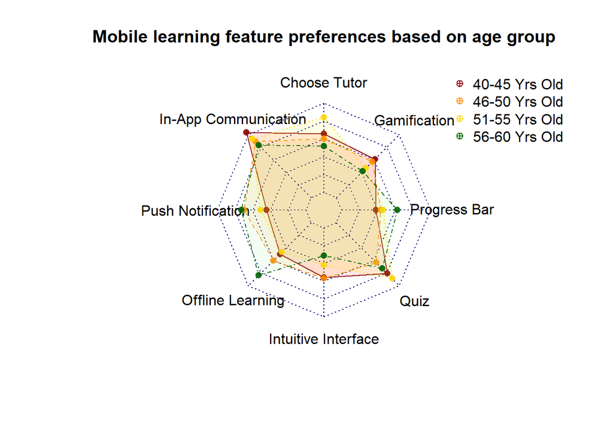

```r
radarchart(df1,
           seg = 5,  # Number of axis segments
           title = "Mobile learning feature preferences based on age group",
           pcol = colors_line,
           pfcol = colors_fill,
           plwd = 1)

legend(x=1.15,
       y=1.35,
       legend = rownames(df1[-c(1,2),]),
       bty = "n", pch=10 , col = colors_line, cex = 1.00, pt.cex = 1.0)
```

```r
data.pref <- data.E6
data.pref$C2 <- rawData$C2

a_level <- function(lvl){
  if (lvl == 'Basic / Tahap Asas'){
    return('Basic')
  }else if(lvl == 'Intermediate / Tahap Pertengahan'){
    return('Intermediate')
  }else if (lvl == 'None / Tiada asas'){
    return('None')
  }else if (lvl == 'Tahap Pertengahan sehingga tingkatan 6'){
    return('Intermediate')
  }
}

data.pref$alevel <- sapply(data.pref$C2,a_level)
#churn_df$tenure_group <- as.factor(churn_df$tenure_group)

df <- subset(data.pref, select=-C2)
df <- subset(df, select=-O9)

colnames(df) <- c('O1','O2','O3','O4','O5','O6','O7','O8','level')

test <- df %>% group_by(level) %>%
  summarise(O1=sum(O1),O2=sum(O2),O3=sum(O3),O4=sum(O4),O5=sum(O5),O6=sum(O6),O7=sum(O7),O8=sum(O8))
#  summarise(O1=sum(O1)*100/nrow(data.pref),O2=sum(O2)*100/nrow(data.pref),O3=sum(O3)*100/nrow(data.pref),O4=sum(O4)*#100/nrow(data.pref),O5=sum(O5)*100/nrow(data.pref),O6=sum(O6)*100/nrow(data.pref),O7=sum(O7)*100/nrow(data.pref),O8=#sum(O8)*100/nrow(data.pref),O9=sum(O9)*100/nrow(data.pref))
test
```

```
## # A tibble: 3 x 9
##   level           O1    O2    O3    O4    O5    O6    O7    O8
##   <chr>        <int> <int> <int> <int> <int> <int> <int> <int>
## 1 Basic           45    74    38    37    37    54    32    40
## 2 Intermediate     1     5     4     4     4     7     5     6
## 3 None            49    60    34    36    34    50    24    35
```

```r
df <- subset(test, select=-level)

scl <- rowSums(df)
v1 <- df[1,]*100/scl[1]
v2 <- df[2,]*100/scl[2]
v3 <- df[3,]*100/scl[3]
#v4 <- df[4,]*100/scl[4]

df1 <- data.frame(rbind(rep(20,8),rep(0,8),v1,v2,v3))

rownames(df1) <- c('max','min','Basic','Intermediate','None')
#colnames(df1) <- c('Choose tutor','In-App communication','Push Notification','Offline learning','Intuitive #Interface','Quiz','Progress bar','Gamification','Flexible learning')
colnames(df1) <- c('Choose Tutor','In-App Communication','Push Notification','Offline Learning','Intuitive Interface','Quiz','Progress Bar','Gamification')
df1
```

```
##              Choose Tutor In-App Communication Push Notification
## max             20.000000             20.00000          20.00000
## min              0.000000              0.00000           0.00000
## Basic           12.605042             20.72829          10.64426
## Intermediate     2.777778             13.88889          11.11111
## None            15.217391             18.63354          10.55901
##              Offline Learning Intuitive Interface     Quiz Progress Bar
## max                  20.00000            20.00000 20.00000    20.000000
## min                   0.00000             0.00000  0.00000     0.000000
## Basic                10.36415            10.36415 15.12605     8.963585
## Intermediate         11.11111            11.11111 19.44444    13.888889
## None                 11.18012            10.55901 15.52795     7.453416
##              Gamification
## max              20.00000
## min               0.00000
## Basic            11.20448
## Intermediate     16.66667
## None             10.86957
```

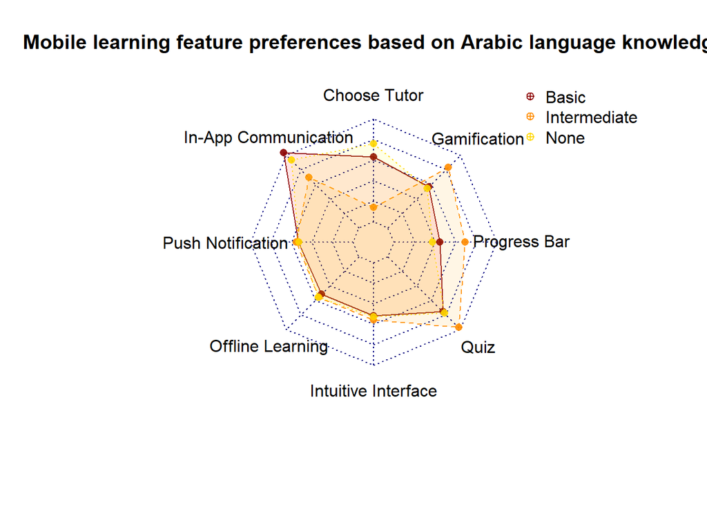

```r
radarchart(df1,
           seg = 5,  # Number of axis segments
           title = "Mobile learning feature preferences based on Arabic language knowledge",
           pcol = colors_line,
           pfcol = colors_fill,
           plwd = 1)

legend(x=1.15,
       y=1.35,
       legend = rownames(df1[-c(1,2),]),
       bty = "n", pch=10 , col = colors_line, cex = 1.00, pt.cex = 1.0)
```

## Cronbach’s Alpha

### Factors

Christensen & Knezek (2017) developed MLRS to measure the report of teacher’s acceptance and readiness in a mobile learning environment. Four factors related to various aspects of mobile learning readiness were identified, with readiness interpreted as the level of acceptance or willingness to incorporate mobile technologies into mobile learning environment.

- Factor 1: Possibilities, related to future possibilities
- Factor 2: Benefits, related to practices for improving classroom instruction
- Factor 3: Preferences, related to mobile device preferences
- Factor 4: External Influences, related to the environment context

By using the same Factors, new survey were constructed in this study as the research instrument to measure the report of student’s acceptance and readiness in a mobile learning environment.

Internal consistency reliabilities for this set of data are listed below. Guidelines provided by DeVellis (2017) stated that ranges of Cronbach’s Alpha values should be between minimally acceptable (.6 or greater) to excellent (.9 or greater).

```r
factors2.f1 <- factors[,c('D1','D3','G1','G4','G9','G10')]
#factors2.f1 <- factors[,c('C2','C3','D1','D3','G1','G4','G9','G10')]
factors2.f2 <- factors[,c('F1','F2','F3','F4','F5','F6','F7','F8','F9','G5','G6','G8','G11','G12')]
#factors2.f3 <- factors[,c('E1','E2','E3','E4','E5','G2','G3','G7','G15')]
factors2.f3 <- factors[,c('B1','C4','E1','E2','E3','E4','E5','G2','G3','G7','G15')]
factors2.f4 <- factors[,c('D2','D4','D5','D6','D7','D8','G13','G14')]

alpha2.f1 <- psych::alpha(factors2.f1, check.keys = TRUE)
alpha2.f2 <- psych::alpha(factors2.f2, check.keys = TRUE)
alpha2.f3 <- psych::alpha(factors2.f3, check.keys = TRUE)
alpha2.f4 <- psych::alpha(factors2.f4, check.keys = TRUE)

alpha2.f <- c(alpha2.f1$total$raw_alpha,alpha2.f2$total$raw_alpha,alpha2.f3$total$raw_alpha,alpha2.f4$total$raw_alpha)

icr <- data.frame(c("F1 (Possibilities)","F2 (Benefits)","F3 (Preferences)","F4 (External Influences)"),
                  alpha2.f,
                  c(length(factors2.f1),length(factors2.f2),length(factors2.f3),length(factors2.f4)))

names(icr)[1] <- "Factors"
names(icr)[2] <- "Cronbach's Alpha"
names(icr)[3] <- "No. of Items"
icr
```

```
##                    Factors Cronbach's Alpha No. of Items
## 1       F1 (Possibilities)        0.6243913            6
## 2            F2 (Benefits)        0.7894040           14
## 3         F3 (Preferences)        0.7080675           11
## 4 F4 (External Influences)        0.6495678            8
```

Descriptive statistics for the mobile learning readiness factors are listed below.

```r
#######################

vector2.f1 <- unlist(factors2.f1[,])
vector2.f2 <- unlist(factors2.f2[,])
vector2.f3 <- unlist(factors2.f3[,])
vector2.f4 <- unlist(factors2.f4[,])

ds <- data.frame(c("F1 (Possibilities)","F2 (Benefits)","F3 (Preferences)","F4 (External Influences)"),
                 c(nrow(factors2.f1),nrow(factors2.f2),nrow(factors2.f3),nrow(factors2.f4)),
                 c(mean(vector2.f1),mean(vector2.f2),mean(vector2.f3),mean(vector2.f4)),
                 c(sd(vector2.f1),sd(vector2.f2),sd(vector2.f3),sd(vector2.f4)))

names(ds)[1] <- "Factors"
names(ds)[2] <- "N"
names(ds)[3] <- "Mean"
names(ds)[4] <- "SD"
ds
```

```
##                    Factors   N      Mean        SD
## 1       F1 (Possibilities) 168 0.8690476 0.2659309
## 2            F2 (Benefits) 168 0.9428146 0.1851099
## 3         F3 (Preferences) 168 0.9364177 0.1985043
## 4 F4 (External Influences) 168 0.8333333 0.3458796
```

### Aspects

Shorfuzzaman & Alhussein (2016) identified six learning aspects need to be considered by students before mobile learning can be adopted. The different aspects of mobile learning that need to be considered are:

- Learners’ readiness - to adopt mobile learning
- Learners’ mobility
- Educators’ willingness - to adopt mobile learning
- Device ubiquity
- Driving factors - direct towards learners’ acceptance
- Software diversity - diversity of tools used

By using similar aspects, four mobile learning aspects were identified to be measured in this study. These aspects are:

- Aspect 1: Awareness
- Aspect 2: Ability
- Aspect 3: Driving factors
- Aspect 4: Software diversity

Internal consistency reliabilities for this set of data are listed below. Guidelines provided by DeVellis (2017) stated that ranges of Cronbach’s Alpha values should be between minimally acceptable (.6 or greater) to excellent (.9 or greater).

```r
aspects.a1 <- aspects[,c('F1','F2','F3','F4','F5','F6','F7','F8','F9','G1','G5','G6','G8','G11','G12')]
aspects.a2 <- aspects[,c('D1','D2','D3','D4','D5','D6','D7','D8','G13','G14')]
#aspects.a3old <- aspects[,c('B1','B2')] # devices
aspects.a3 <- aspects[,c('C4','G4','G9','G10')]
#aspects.a3 <- aspects[,c('C2','C3','C4','G4','G9','G10')]
#aspects.a3 <- aspects[,c('C3','C4','G4','G9','G10')]
aspects.a4 <- aspects[,c('E1','E2','E3','E4','E5','G2','G3','G7','G15')]

alpha.a1 <- psych::alpha(aspects.a1, check.keys = TRUE)
alpha.a2 <- psych::alpha(aspects.a2, check.keys = TRUE)
#alpha.a3old <- psych::alpha(aspects.a3old, check.keys = TRUE)
alpha.a3 <- psych::alpha(aspects.a3, check.keys = TRUE)
alpha.a4 <- psych::alpha(aspects.a4, check.keys = TRUE)

#alpha.a <- c(alpha.a1$total$raw_alpha,alpha.a2$total$raw_alpha,alpha.a3$total$raw_alpha,alpha.a4$total$raw_alpha,alpha.a5$total$raw_alpha)
alpha.a <- c(alpha.a1$total$raw_alpha,alpha.a2$total$raw_alpha,alpha.a3$total$raw_alpha,alpha.a4$total$raw_alpha)

#icr.a <- data.frame(c("A1 (Awareness)","A2 (Ability)","A3 (Devices)","A4 (Driving Factors)","A5 (Software Diversity)"),
#                  alpha.a,
#                  c(length(aspects.a1),length(aspects.a2),length(aspects.a3),length(aspects.a4),length(aspects.a5)))
icr.a <- data.frame(c("A1 (Awareness)","A2 (Ability)","A3 (Driving Factors)","A4 (Software Diversity)"),
                  alpha.a,
                  c(length(aspects.a1),length(aspects.a2),length(aspects.a3),length(aspects.a4)))

names(icr.a)[1] <- "Aspects"
names(icr.a)[2] <- "Cronbach's Alpha"
names(icr.a)[3] <- "No. of Items"
icr.a
```

```
##                   Aspects Cronbach's Alpha No. of Items
## 1          A1 (Awareness)        0.7975614           15
## 2            A2 (Ability)        0.6531361           10
## 3    A3 (Driving Factors)        0.6650176            4
## 4 A4 (Software Diversity)        0.7098510            9
```

Descriptive statistics for the mobile learning readiness aspects are listed below.

```r
#######################

vector.a1 <- unlist(aspects.a1[,])
vector.a2 <- unlist(aspects.a2[,])
#vector.a3old <- unlist(aspects.a3old[,])
vector.a3 <- unlist(aspects.a3[,])
vector.a4 <- unlist(aspects.a4[,])

ds.a <- data.frame(c("A1 (Awareness)","A2 (Ability)","A3 (Driving Factors)","A4 (Software Diversity)"),
                 c(nrow(aspects.a1),nrow(aspects.a2),nrow(aspects.a3),nrow(aspects.a4)),
                 c(mean(vector.a1),mean(vector.a2),mean(vector.a3),mean(vector.a4)),
                 c(sd(vector.a1),sd(vector.a2),sd(vector.a3),sd(vector.a4)))

names(ds.a)[1] <- "Aspects"
names(ds.a)[2] <- "N"
names(ds.a)[3] <- "Mean"
names(ds.a)[4] <- "SD"
ds.a
```

```
##                   Aspects   N      Mean        SD
## 1          A1 (Awareness) 168 0.9375000 0.1910110
## 2            A2 (Ability) 168 0.8485119 0.3339053
## 3    A3 (Driving Factors) 168 0.8712798 0.2549530
## 4 A4 (Software Diversity) 168 0.9282407 0.2057482
```

### Factors Old Calculation

About factors, F1 F2 F3 F4

```r
factors.f1 <- factors[,c('D1','D3','G1','G4','G9','G10')]
factors.f2 <- factors[,c('F1','F2','F3','F4','F5','F6','F7','F8','F9','G5','G8','G11','G12')]
factors.f3 <- factors[,c('E1','E2','E3','E4','E5','G2','G3','G7')]
factors.f4 <- factors[,c('D2','D4','D5','D6','D7','D8','G14')]

alpha.f1 <- psych::alpha(factors.f1, check.keys = TRUE)
alpha.f2 <- psych::alpha(factors.f2, check.keys = TRUE)
alpha.f3 <- psych::alpha(factors.f3, check.keys = TRUE)
alpha.f4 <- psych::alpha(factors.f4, check.keys = TRUE)

alpha.f <- c(alpha.f1$total$raw_alpha,alpha.f2$total$raw_alpha,alpha.f3$total$raw_alpha,alpha.f4$total$raw_alpha)

icr <- data.frame(c("F1 (Possibilities)","F2 (Benefits)","F3 (Preferences)","F4 (External Influences)"),
                  alpha.f,
                  c(length(factors.f1),length(factors.f2),length(factors.f3),length(factors.f4)))

names(icr)[1] <- "Factors"
names(icr)[2] <- "Cronbach's Alpha"
names(icr)[3] <- "No. of Items"
icr
```

```
##                    Factors Cronbach's Alpha No. of Items
## 1       F1 (Possibilities)        0.6243913            6
## 2            F2 (Benefits)        0.7590107           13
## 3         F3 (Preferences)        0.6468087            8
## 4 F4 (External Influences)        0.6252278            7
```

Calculate mean for factors

```r
#######################

vector.f1 <- unlist(factors.f1[,])
vector.f2 <- unlist(factors.f2[,])
vector.f3 <- unlist(factors.f3[,])
vector.f4 <- unlist(factors.f4[,])

ds <- data.frame(c("F1 (Possibilities)","F2 (Benefits)","F3 (Preferences)","F4 (External Influences)"),
                 c(nrow(factors.f1),nrow(factors.f2),nrow(factors.f3),nrow(factors.f4)),
                 c(mean(vector.f1),mean(vector.f2),mean(vector.f3),mean(vector.f4)),
                 c(sd(vector.f1),sd(vector.f2),sd(vector.f3),sd(vector.f4)))

names(ds)[1] <- "Factors"
names(ds)[2] <- "N"
names(ds)[3] <- "Mean"
names(ds)[4] <- "SD"
ds
```

```
##                    Factors   N      Mean        SD
## 1       F1 (Possibilities) 168 0.8690476 0.2659309
## 2            F2 (Benefits) 168 0.9459707 0.1823958
## 3         F3 (Preferences) 168 0.9363839 0.1992369
## 4 F4 (External Influences) 168 0.8239796 0.3603353
```

## Associations

```r
data2 <- as.data.frame(rowMeans(factors2.f1))
names(data2)[1] <- "f1"
data2$f2 <- rowMeans(factors2.f2)
data2$f3 <- rowMeans(factors2.f3)
data2$f4 <- rowMeans(factors2.f4)
data2$a1 <- rowMeans(aspects.a1)
data2$a2 <- rowMeans(aspects.a2)
data2$a3 <- rowMeans(aspects.a3)
data2$a4 <- rowMeans(aspects.a4)

colnames(data2) <- c('F1 Possibilities','F2 Benefits','F3 Preferences','F4 External Influences','A1 Awareness','A2 Ability','A3 Driving Factors','A4 Software Diversity')
```

### A1 Awareness

#### Association of Awareness and Mobile Learning Readiness Factors

Based on Analysis of Variance:

- Significant contributors are F1 (Possibilities) and F2 (Benefits) with p<0.0005
- The least significant contributor is F4 (External Influences)

```r
mod.a1 <- lm(`A1 Awareness` ~ `F1 Possibilities`+`F2 Benefits`+`F3 Preferences`+`F4 External Influences`, data=data2)
anova(mod.a1)
```

```
## Analysis of Variance Table
##
## Response: A1 Awareness
##                           Df  Sum Sq Mean Sq   F value    Pr(>F)
## `F1 Possibilities`         1 0.87657 0.87657 5059.8507 < 2.2e-16 ***
## `F2 Benefits`              1 0.57992 0.57992 3347.4713 < 2.2e-16 ***
## `F3 Preferences`           1 0.00170 0.00170    9.8316  0.002035 **
## `F4 External Influences`   1 0.00065 0.00065    3.7731  0.053807 .
## Residuals                163 0.02824 0.00017
## ---
## Signif. codes:  0 '***' 0.001 '**' 0.01 '*' 0.05 '.' 0.1 ' ' 1
```

Based on Regression Analysis:

- The most significant contributor is F2 (Benefits) with p<2e-16, followed by F1 (Possibilities) with p=2.86e-10
- The least contributor is F4 (External Influences) with p=0.05381

```r
summary(mod.a1)
```

```
##
## Call:
## lm(formula = `A1 Awareness` ~ `F1 Possibilities` + `F2 Benefits` +
##     `F3 Preferences` + `F4 External Influences`, data = data2)
##
## Residuals:
##       Min        1Q    Median        3Q       Max
## -0.053609 -0.003852  0.000590  0.007158  0.028153
##
## Coefficients:
##                           Estimate Std. Error t value Pr(>|t|)
## (Intercept)              -0.008169   0.011447  -0.714  0.47646
## `F1 Possibilities`        0.074366   0.011063   6.722 2.86e-10 ***
## `F2 Benefits`             0.903147   0.018005  50.160  < 2e-16 ***
## `F3 Preferences`          0.043521   0.013903   3.130  0.00207 **
## `F4 External Influences` -0.013454   0.006926  -1.942  0.05381 .
## ---
## Signif. codes:  0 '***' 0.001 '**' 0.01 '*' 0.05 '.' 0.1 ' ' 1
##
## Residual standard error: 0.01316 on 163 degrees of freedom
## Multiple R-squared:  0.981,  Adjusted R-squared:  0.9805
## F-statistic:  2105 on 4 and 163 DF,  p-value: < 2.2e-16
```

```r
confint(mod.a1)
```

```
##                                2.5 %       97.5 %
## (Intercept)              -0.03077269 0.0144342169
## `F1 Possibilities`        0.05252089 0.0962103545
## `F2 Benefits`             0.86759314 0.9387006535
## `F3 Preferences`          0.01606837 0.0709729655
## `F4 External Influences` -0.02713090 0.0002229117
```

```r
a1.ubeta <- c(summary(mod.a1)$coefficients["(Intercept)","Estimate"],summary(mod.a1)$coefficients["`F1 Possibilities`","Estimate"],summary(mod.a1)$coefficients["`F2 Benefits`","Estimate"],summary(mod.a1)$coefficients["`F3 Preferences`","Estimate"],summary(mod.a1)$coefficients["`F4 External Influences`","Estimate"])
a1.se <- c(summary(mod.a1)$coefficients["(Intercept)","Std. Error"],summary(mod.a1)$coefficients["`F1 Possibilities`","Std. Error"],summary(mod.a1)$coefficients["`F2 Benefits`","Std. Error"],summary(mod.a1)$coefficients["`F3 Preferences`","Std. Error"],summary(mod.a1)$coefficients["`F4 External Influences`","Std. Error"])
a1.tvalue <- c(summary(mod.a1)$coefficients["(Intercept)","t value"],summary(mod.a1)$coefficients["`F1 Possibilities`","t value"],summary(mod.a1)$coefficients["`F2 Benefits`","t value"],summary(mod.a1)$coefficients["`F3 Preferences`","t value"],summary(mod.a1)$coefficients["`F4 External Influences`","t value"])
a1.sig <- c(summary(mod.a1)$coefficients["(Intercept)","Pr(>|t|)"],summary(mod.a1)$coefficients["`F1 Possibilities`","Pr(>|t|)"],summary(mod.a1)$coefficients["`F2 Benefits`","Pr(>|t|)"],summary(mod.a1)$coefficients["`F3 Preferences`","Pr(>|t|)"],summary(mod.a1)$coefficients["`F4 External Influences`","Pr(>|t|)"])

a1.sbeta <- c('NA',summary(mod.a1)$coefficients["`F1 Possibilities`","Estimate"]*(sd(data2$`F1 Possibilities`)/sd(data2$`A1 Awareness`)),summary(mod.a1)$coefficients["`F2 Benefits`","Estimate"]*(sd(data2$`F2 Benefits`)/sd(data2$`A1 Awareness`)),summary(mod.a1)$coefficients["`F3 Preferences`","Estimate"]*(sd(data2$`F3 Preferences`)/sd(data2$`A1 Awareness`)),summary(mod.a1)$coefficients["`F4 External Influences`","Estimate"]/(sd(data2$`F4 External Influences`)/sd(data2$`A1 Awareness`)))

a1.table <- data.frame(a1.ubeta,a1.se,a1.sbeta,a1.tvalue,a1.sig)
colnames(a1.table) <- c('B','Std. Error','Beta','t','Sig.')
rownames(a1.table) <- c('(Constant)','F1 (Possibilities)','F2 (Benefits)','F3 (Preferences','F4 (External Influences)')

a1.table
```

```
##                                     B  Std. Error                 Beta
## (Constant)               -0.008169234 0.011446961                   NA
## F1 (Possibilities)        0.074365622 0.011062727    0.113080722491776
## F2 (Benefits)             0.903146897 0.018005324    0.887678803439598
## F3 (Preferences           0.043520666 0.013902541   0.0448467921251053
## F4 (External Influences) -0.013453993 0.006926331 -0.00713043067617967
##                                   t          Sig.
## (Constant)               -0.7136596  4.764583e-01
## F1 (Possibilities)        6.7221784  2.864657e-10
## F2 (Benefits)            50.1599902 5.270225e-101
## F3 (Preferences           3.1304110  2.069106e-03
## F4 (External Influences) -1.9424414  5.380724e-02
```

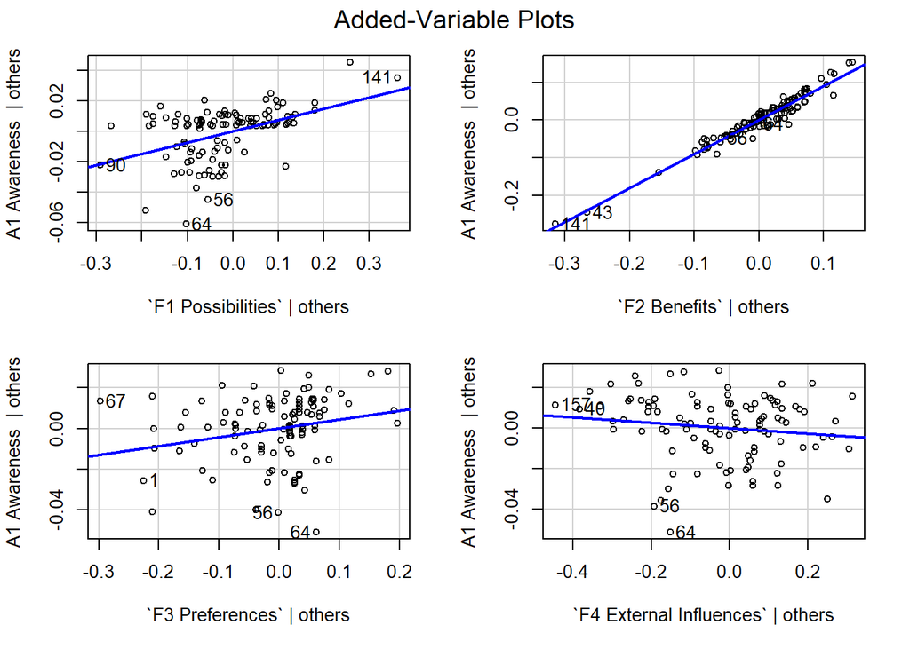

```r
avPlots(mod.a1)
```

Based on Pearson Product Moment Correlations:

- Awareness correlates the highest with F2 (Benefits) = 0.99 (p<0.001), followed by F1 (Possibilities) = 0.77 (p<0.001)
- Awareness correlates the lowest with F4 (External Influences) = 0.48 (p<0.001)

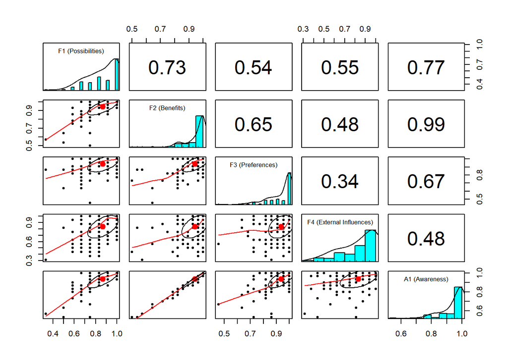

```r
data.a1 <- as.data.frame(rowMeans(factors2.f1))
names(data.a1)[1] <- "f1"
data.a1$f2 <- rowMeans(factors2.f2)
data.a1$f3 <- rowMeans(factors2.f3)
data.a1$f4 <- rowMeans(factors2.f4)
data.a1$a1 <- rowMeans(aspects.a1)

colnames(data.a1) <- c('F1 (Possibilities)','F2 (Benefits)','F3 (Preferences)','F4 (External Influences)','A1 (Awareness)')

pairs.panels(data.a1)
```

```r
cor(data.a1,method=c("pearson"))
```

```
##                          F1 (Possibilities) F2 (Benefits) F3 (Preferences)
## F1 (Possibilities)                1.0000000     0.7261724        0.5376028
## F2 (Benefits)                     0.7261724     1.0000000        0.6507084
## F3 (Preferences)                  0.5376028     0.6507084        1.0000000
## F4 (External Influences)          0.5529806     0.4772659        0.3373391
## A1 (Awareness)                    0.7677607     0.9868614        0.6746958
##                          F4 (External Influences) A1 (Awareness)
## F1 (Possibilities)                      0.5529806      0.7677607
## F2 (Benefits)                           0.4772659      0.9868614
## F3 (Preferences)                        0.3373391      0.6746958
## F4 (External Influences)                1.0000000      0.4759333
## A1 (Awareness)                          0.4759333      1.0000000
```

```r
correlation::correlation(data.a1,include_factors = TRUE, method = "pearson")
```

```
## # Correlation Matrix (pearson-method)
##
## Parameter1               |               Parameter2 |    r |       95% CI | t(166) |         p
## ----------------------------------------------------------------------------------------------
## F1 (Possibilities)       |            F2 (Benefits) | 0.73 | [0.65, 0.79] |  13.61 | < .001***
## F1 (Possibilities)       |         F3 (Preferences) | 0.54 | [0.42, 0.64] |   8.21 | < .001***
## F1 (Possibilities)       | F4 (External Influences) | 0.55 | [0.44, 0.65] |   8.55 | < .001***
## F1 (Possibilities)       |           A1 (Awareness) | 0.77 | [0.70, 0.82] |  15.44 | < .001***
## F2 (Benefits)            |         F3 (Preferences) | 0.65 | [0.55, 0.73] |  11.04 | < .001***
## F2 (Benefits)            | F4 (External Influences) | 0.48 | [0.35, 0.59] |   7.00 | < .001***
## F2 (Benefits)            |           A1 (Awareness) | 0.99 | [0.98, 0.99] |  78.70 | < .001***
## F3 (Preferences)         | F4 (External Influences) | 0.34 | [0.20, 0.46] |   4.62 | < .001***
## F3 (Preferences)         |           A1 (Awareness) | 0.67 | [0.58, 0.75] |  11.78 | < .001***
## F4 (External Influences) |           A1 (Awareness) | 0.48 | [0.35, 0.59] |   6.97 | < .001***
##
## p-value adjustment method: Holm (1979)
## Observations: 168
```

### A2 Ability

#### Association of Ability and Mobile Learning Readiness Factors

Based on Analysis of Variance:

- Significant contributors are F1 (Possibilities)and F4 (External Influences) with p<0.0005
- The least significant contributor is F2 (Benefits)

```r
mod.a2 <- lm(`A2 Ability` ~ `F1 Possibilities`+`F2 Benefits`+`F3 Preferences`+`F4 External Influences`, data=data2)
anova(mod.a2)
```

```
## Analysis of Variance Table
##
## Response: A2 Ability
##                           Df  Sum Sq Mean Sq   F value    Pr(>F)
## `F1 Possibilities`         1 1.51704 1.51704 1447.2446 < 2.2e-16 ***
## `F2 Benefits`              1 0.00176 0.00176    1.6753  0.197381
## `F3 Preferences`           1 0.00938 0.00938    8.9441  0.003216 **
## `F4 External Influences`   1 2.45310 2.45310 2340.2347 < 2.2e-16 ***
## Residuals                163 0.17086 0.00105
## ---
## Signif. codes:  0 '***' 0.001 '**' 0.01 '*' 0.05 '.' 0.1 ' ' 1
```

Based on regression analysis:

- The most significant contributor is F4 (External Influences) with p<2e-16, followed by F1 (Possibilities) with p<2e-16, then F2 (Benefits) with p=9.2e-08
- The least contributor is F3 (Preferences) with p=0.00474

```r
summary(mod.a2)
```

```
##
## Call:
## lm(formula = `A2 Ability` ~ `F1 Possibilities` + `F2 Benefits` +
##     `F3 Preferences` + `F4 External Influences`, data = data2)
##
## Residuals:
##       Min        1Q    Median        3Q       Max
## -0.111737 -0.007210  0.001692  0.019690  0.087179
##
## Coefficients:
##                          Estimate Std. Error t value Pr(>|t|)
## (Intercept)               0.26912    0.02816   9.558  < 2e-16 ***
## `F1 Possibilities`        0.25064    0.02721   9.210  < 2e-16 ***
## `F2 Benefits`            -0.24774    0.04429  -5.594  9.2e-08 ***
## `F3 Preferences`         -0.09792    0.03420  -2.863  0.00474 **
## `F4 External Influences`  0.82421    0.01704  48.376  < 2e-16 ***
## ---
## Signif. codes:  0 '***' 0.001 '**' 0.01 '*' 0.05 '.' 0.1 ' ' 1
##
## Residual standard error: 0.03238 on 163 degrees of freedom
## Multiple R-squared:  0.9588, Adjusted R-squared:  0.9578
## F-statistic: 949.5 on 4 and 163 DF,  p-value: < 2.2e-16
```

```r
confint(mod.a2)
```

```
##                               2.5 %      97.5 %
## (Intercept)               0.2135207  0.32472138
## `F1 Possibilities`        0.1969041  0.30437219
## `F2 Benefits`            -0.3351960 -0.16028448
## `F3 Preferences`         -0.1654443 -0.03038905
## `F4 External Influences`  0.7905635  0.85784883
```

```r
a2.ubeta <- c(summary(mod.a2)$coefficients["(Intercept)","Estimate"],summary(mod.a2)$coefficients["`F1 Possibilities`","Estimate"],summary(mod.a2)$coefficients["`F2 Benefits`","Estimate"],summary(mod.a2)$coefficients["`F3 Preferences`","Estimate"],summary(mod.a2)$coefficients["`F4 External Influences`","Estimate"])
a2.se <- c(summary(mod.a2)$coefficients["(Intercept)","Std. Error"],summary(mod.a2)$coefficients["`F1 Possibilities`","Std. Error"],summary(mod.a2)$coefficients["`F2 Benefits`","Std. Error"],summary(mod.a2)$coefficients["`F3 Preferences`","Std. Error"],summary(mod.a2)$coefficients["`F4 External Influences`","Std. Error"])
a2.tvalue <- c(summary(mod.a2)$coefficients["(Intercept)","t value"],summary(mod.a2)$coefficients["`F1 Possibilities`","t value"],summary(mod.a2)$coefficients["`F2 Benefits`","t value"],summary(mod.a2)$coefficients["`F3 Preferences`","t value"],summary(mod.a2)$coefficients["`F4 External Influences`","t value"])
a2.sig <- c(summary(mod.a2)$coefficients["(Intercept)","Pr(>|t|)"],summary(mod.a2)$coefficients["`F1 Possibilities`","Pr(>|t|)"],summary(mod.a2)$coefficients["`F2 Benefits`","Pr(>|t|)"],summary(mod.a2)$coefficients["`F3 Preferences`","Pr(>|t|)"],summary(mod.a2)$coefficients["`F4 External Influences`","Pr(>|t|)"])

a2.sbeta <- c('NA',summary(mod.a2)$coefficients["`F1 Possibilities`","Estimate"]*(sd(data2$`F1 Possibilities`)/sd(data2$`A2 Ability`)),summary(mod.a2)$coefficients["`F2 Benefits`","Estimate"]*(sd(data2$`F2 Benefits`)/sd(data2$`A2 Ability`)),summary(mod.a2)$coefficients["`F3 Preferences`","Estimate"]*(sd(data2$`F3 Preferences`)/sd(data2$`A2 Ability`)),summary(mod.a2)$coefficients["`F4 External Influences`","Estimate"]/(sd(data2$`F4 External Influences`)/sd(data2$`A2 Ability`)))

a2.table <- data.frame(a2.ubeta,a2.se,a2.sbeta,a2.tvalue,a2.sig)
colnames(a2.table) <- c('B','Std. Error','Beta','t','Sig.')
rownames(a2.table) <- c('(Constant)','F1 (Possibilities)','F2 (Benefits)','F3 (Preferences','F4 (External Influences)')

a2.table
```

```
##                                    B Std. Error                Beta         t
## (Constant)                0.26912102 0.02815743                  NA  9.557725
## F1 (Possibilities)        0.25063814 0.02721229    0.22808451582789  9.210476
## F2 (Benefits)            -0.24774024 0.04428981   -0.14572239231714 -5.593617
## F3 (Preferences          -0.09791669 0.03419771 -0.0603844145080526 -2.863253
## F4 (External Influences)  0.82420614 0.01703751    0.72990802134586 48.375972
##                                  Sig.
## (Constant)               1.834644e-17
## F1 (Possibilities)       1.557385e-16
## F2 (Benefits)            9.199712e-08
## F3 (Preferences          4.744578e-03
## F4 (External Influences) 1.333615e-98
```

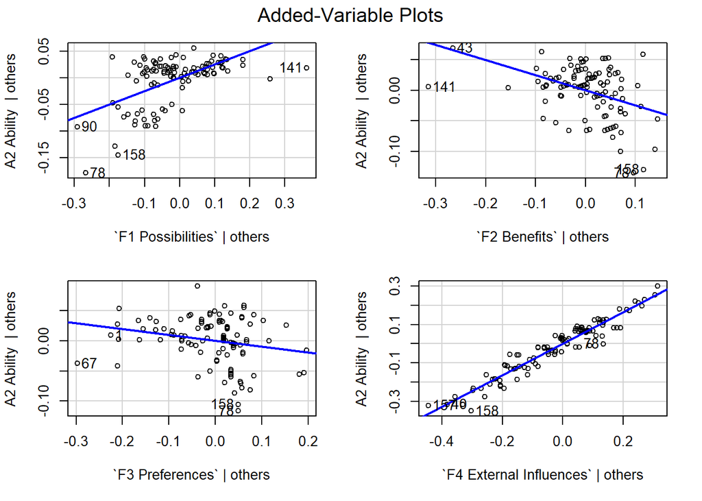

```r
avPlots(mod.a2)
```

Based on Pearson Product Moment Correlations:

- Ability correlates the highest with F4 (External Influences) = 0.97 (p<0.001), followed by F1 (Possibilities) = 0.60 (p<0.001)
- Ability correlates the lowest with F3 (Preferences) = 0.28 (p<0.001)

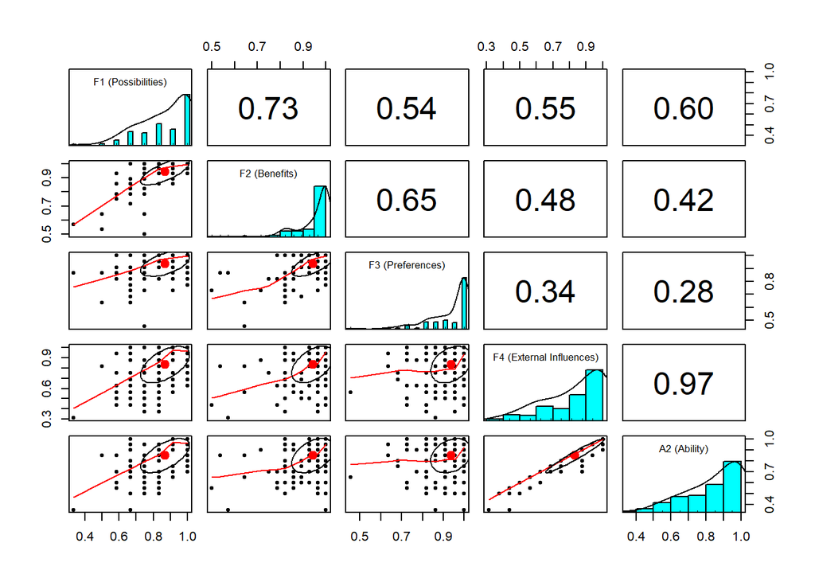

```r
data.a2 <- as.data.frame(rowMeans(factors2.f1))
names(data.a2)[1] <- "f1"
data.a2$f2 <- rowMeans(factors2.f2)
data.a2$f3 <- rowMeans(factors2.f3)
data.a2$f4 <- rowMeans(factors2.f4)
data.a2$a2 <- rowMeans(aspects.a2)

colnames(data.a2) <- c('F1 (Possibilities)','F2 (Benefits)','F3 (Preferences)','F4 (External Influences)','A2 (Ability)')

pairs.panels(data.a2)
```

```r
cor(data.a2,method=c("pearson"))
```

```
##                          F1 (Possibilities) F2 (Benefits) F3 (Preferences)
## F1 (Possibilities)                1.0000000     0.7261724        0.5376028
## F2 (Benefits)                     0.7261724     1.0000000        0.6507084
## F3 (Preferences)                  0.5376028     0.6507084        1.0000000
## F4 (External Influences)          0.5529806     0.4772659        0.3373391
## A2 (Ability)                      0.6044538     0.4247987        0.2813688
##                          F4 (External Influences) A2 (Ability)
## F1 (Possibilities)                      0.5529806    0.6044538
## F2 (Benefits)                           0.4772659    0.4247987
## F3 (Preferences)                        0.3373391    0.2813688
## F4 (External Influences)                1.0000000    0.9668948
## A2 (Ability)                            0.9668948    1.0000000
```

```r
correlation::correlation(data.a2,include_factors = TRUE, method = "pearson")
```

```
## # Correlation Matrix (pearson-method)
##
## Parameter1               |               Parameter2 |    r |       95% CI | t(166) |         p
## ----------------------------------------------------------------------------------------------
## F1 (Possibilities)       |            F2 (Benefits) | 0.73 | [0.65, 0.79] |  13.61 | < .001***
## F1 (Possibilities)       |         F3 (Preferences) | 0.54 | [0.42, 0.64] |   8.21 | < .001***
## F1 (Possibilities)       | F4 (External Influences) | 0.55 | [0.44, 0.65] |   8.55 | < .001***
## F1 (Possibilities)       |             A2 (Ability) | 0.60 | [0.50, 0.69] |   9.78 | < .001***
## F2 (Benefits)            |         F3 (Preferences) | 0.65 | [0.55, 0.73] |  11.04 | < .001***
## F2 (Benefits)            | F4 (External Influences) | 0.48 | [0.35, 0.59] |   7.00 | < .001***
## F2 (Benefits)            |             A2 (Ability) | 0.42 | [0.29, 0.54] |   6.05 | < .001***
## F3 (Preferences)         | F4 (External Influences) | 0.34 | [0.20, 0.46] |   4.62 | < .001***
## F3 (Preferences)         |             A2 (Ability) | 0.28 | [0.14, 0.42] |   3.78 | < .001***
## F4 (External Influences) |             A2 (Ability) | 0.97 | [0.96, 0.98] |  48.82 | < .001***
##
## p-value adjustment method: Holm (1979)
## Observations: 168
```